## Visual Analysis of Elon Musk’s Tweets

#### By [Devin Didericksen](http://linkedin.com/in/didericksen) on October 11, 2014

### Count of Tweets by Elon Musk Grouped by Topic

### Charting the Data

To get the data I used the Twitter API and the python script [tweet_dumper.py](https://gist.github.com/yanofsky/5436496) to pull all of Elon’s tweets. I only used tweets and retweets (no replies or favorites). I then categorized them based on their content into “Tesla”, “SpaceX”, “SolarCity”, and “Other”. Most of his tweets and retweets are directly related to one of his three companies. Of the “Other” tweets, most are about climate change (which incidentally is a driving influence for his involvement in all three companies).

Special thanks to Ramnath Vaidyanathan, Hadley Wickham, and Yihui Xie for their R packages, and to Novus Partners for NVD3.

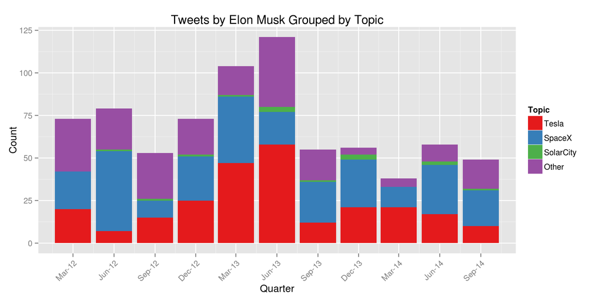